# Statistical Methods - Homework 1

Bilal Hamdan

2026-10-29

## FSDS - Chapter 2

### Exercise 2.21

**Question:** Plot the Gamma distribution with shape parameter k = 3 and scale parameters 0.5, 1, 2, 3, 4, 5. What is the effect of increasing the scale parameter?

**Solution:**

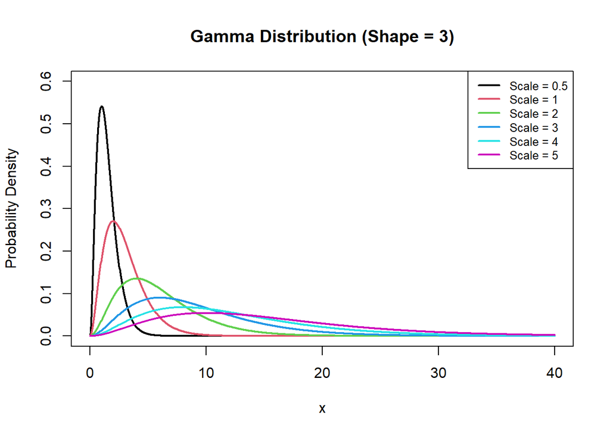

```r
# Set the shape and scale parameters
k <- 3
scales <- c(0.5, 1, 2, 3, 4, 5)

# Create x values
x <- seq(0, 40, length.out = 1000)

# Plot the first Gamma distribution
plot(x, dgamma(x, shape = k, scale = scales[1]),
     type = "l", col = 1, lwd = 2,
     ylim = c(0, 0.6),
     xlab = "x", ylab = "Probability Density",
     main = "Gamma Distribution (Shape = 3)")

# Add the other distributions
for (i in 2:length(scales)) {
  lines(x, dgamma(x, shape = k, scale = scales[i]),
        col = i, lwd = 2)
}

# Add the legend
legend("topright",
       legend = paste("Scale =", scales),
       col = 1:6, lwd = 2, cex = 0.8)
```

**Interpretation:**

Increasing the scale parameter makes the Gamma distribution more spread out and shifts it toward larger values.

The mean and variance of a Gamma distribution are:

$$E(X) = k\theta$$

$$Var(X) = k\theta^2$$

Since the shape parameter k = 3 remains fixed, increasing the scale parameter increases both the mean and the variance.

The density curve becomes wider and flatter, while its total area remains equal to 1.

### Exercise 2.26

**Question:** Refer to Table 2.4, cross-classifying happiness with family income.

1. Find and interpret the correlation using scores:
2. (1, 2, 3) for each variable;
2. (1, 2, 3) for income and (1, 4, 5) for happiness.
2. Construct the joint distribution with the same marginal distributions, assuming independence.

**Solution (a): Correlation**

```r
# Joint probability distribution from Table 2.4
P <- matrix(c(0.080, 0.198, 0.079,
              0.043, 0.254, 0.143,
              0.017, 0.105, 0.081),
            nrow = 3, byrow = TRUE)

# Marginal probabilities
px <- rowSums(P)
py <- colSums(P)

# Income scores
x <- c(1, 2, 3)

# Function to calculate correlation
joint_cor <- function(x, y, P) {
  px <- rowSums(P)
  py <- colSums(P)

  EX <- sum(x * px)
  EY <- sum(y * py)

  EXY <- sum(outer(x, y) * P)

  covXY <- EXY - EX * EY

  varX <- sum(x^2 * px) - EX^2
  varY <- sum(y^2 * py) - EY^2

  covXY / sqrt(varX * varY)
}

# Scoring system (i)
cor1 <- joint_cor(x, c(1, 2, 3), P)

# Scoring system (ii)
cor2 <- joint_cor(x, c(1, 4, 5), P)

round(c(System_i = cor1, System_ii = cor2), 4)
```

```
##  System_i System_ii
##    0.1907    0.1898
```

**Interpretation:**

For scoring system (i), the correlation is approximately 0.1907. For scoring system (ii), it is approximately 0.1898.

Both values indicate a weak positive association between family income and happiness. The small difference shows that the numerical scores assigned to ordinal categories can affect the correlation.

**Solution (b): Independence**

```r
# Joint probabilities under independence
P_independent <- outer(px, py)

rownames(P_independent) <- c("Below average",
                             "Average",
                             "Above average")

colnames(P_independent) <- c("Not too happy",
                             "Pretty happy",
                             "Very happy")

round(P_independent, 6)
```

```
##               Not too happy Pretty happy Very happy
## Below average       0.04998     0.198849   0.108171
## Average             0.06160     0.245080   0.133320
## Above average       0.02842     0.113071   0.061509
```

```r
# Check that the marginals are unchanged
rowSums(P_independent)
```

```
## Below average       Average Above average
##         0.357         0.440         0.203
```

```r
colSums(P_independent)
```

```
## Not too happy  Pretty happy    Very happy
##         0.140         0.557         0.303
```

**Interpretation:**

The independent joint distribution is obtained by multiplying the corresponding marginal probabilities:

$$P(X=x,Y=y)=P(X=x)P(Y=y).$$

The resulting distribution preserves the original marginal probabilities while making family income and happiness independent.

### Exercise 2.52

**Solution (a)**

Let $Y \sim N(\mu,\sigma^2)$ and define the standard normal random variable

$$Z=\frac{Y-\mu}{\sigma}.$$

By the definition of the cumulative distribution function,

$$F(y)=P(Y\leq y).$$

Since $\sigma>0$, standardizing gives

$$F(y)=P\left(\frac{Y-\mu}{\sigma}
\leq\frac{y-\mu}{\sigma}\right).$$

Therefore,

$$\boxed{F(y)=\Phi\left(\frac{y-\mu}{\sigma}\right)}.$$

**Solution (b)**

The probability density function is the derivative of the cumulative distribution function:

$$f(y)=\frac{d}{dy}F(y).$$

Using the result from part (a) and applying the chain rule,

$$f(y)=\phi\left(\frac{y-\mu}{\sigma}\right)
\frac{d}{dy}\left(\frac{y-\mu}{\sigma}\right).$$

Hence,

$$\boxed{f(y)=\frac{1}{\sigma}
\phi\left(\frac{y-\mu}{\sigma}\right)}.$$

From Equation (2.9), the standard normal density is

$$\phi(z)=\frac{1}{\sqrt{2\pi}}e^{-z^2/2}.$$

Substituting gives

$$\boxed{
f(y)=\frac{1}{\sigma\sqrt{2\pi}}
e^{-\frac{(y-\mu)^2}{2\sigma^2}}
}.$$

This is Equation (2.8), the probability density function of a normal distribution.

### Exercise 2.53

**Solution**

Let $Y \sim N(0,1)$ and define $X=\Phi(Y)$, where $\Phi$ is the standard normal cumulative distribution function.

By the probability integral transformation, if $F$ is the continuous CDF of a random variable $Y$, then $F(Y)$ follows a Uniform(0,1) distribution.

Therefore,

$$\boxed{X=\Phi(Y)\sim \mathrm{Uniform}(0,1)}.$$

We verify this result by generating one million standard normal random values and transforming them using the standard normal CDF.

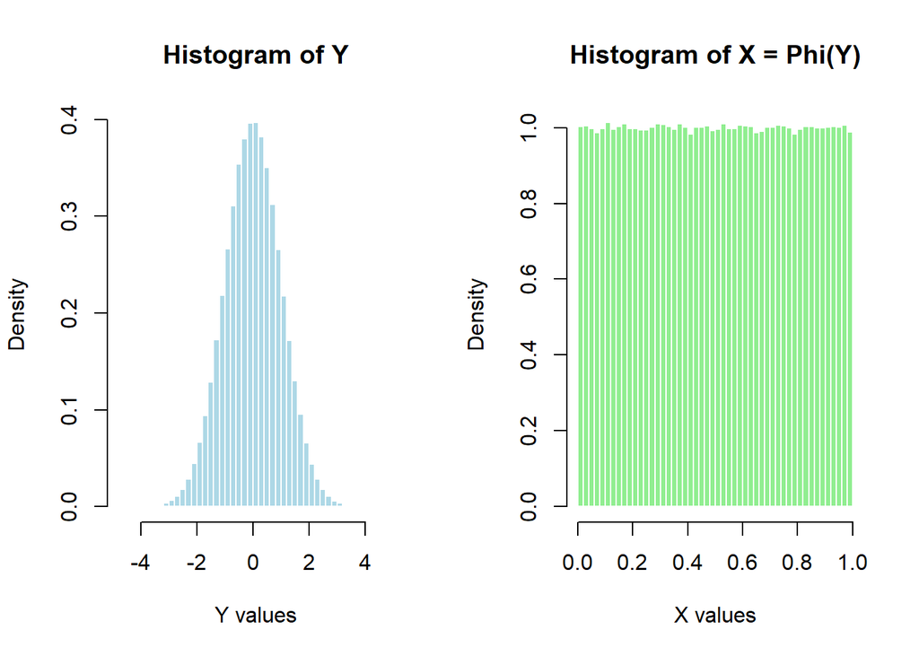

```r
# Generate one million standard normal observations
set.seed(123)
y <- rnorm(1000000, mean = 0, sd = 1)

# Apply the standard normal CDF
x <- pnorm(y)

# Display both histograms side by side
par(mfrow = c(1, 2))

hist(y,
     breaks = 60,
     probability = TRUE,
     main = "Histogram of Y",
     xlab = "Y values",
     col = "lightblue",
     border = "white")

hist(x,
     breaks = 60,
     probability = TRUE,
     main = "Histogram of X = Phi(Y)",
     xlab = "X values",
     col = "lightgreen",
     border = "white")
```

```r
# Restore the default plotting layout
par(mfrow = c(1, 1))
```

**Interpretation**

The histogram of Y is approximately bell-shaped, as expected for a standard normal distribution.

The histogram of X is approximately flat over the interval (0,1), confirming that X follows a Uniform(0,1) distribution.

### Exercise 2.70

**Solution (a): Uniform distribution**

For alpha = beta = 1, the beta density becomes

$$f(y;1,1)=
\frac{\Gamma(2)}{\Gamma(1)\Gamma(1)}
y^0(1-y)^0=1.$$

Thus, for $0\leq y\leq1$, this is the density of a Uniform(0,1) distribution.

**Solution (b): Expected value**

By definition,

$$E(Y)=\int_0^1 yf(y)\,dy.$$

Substituting the beta density,

$$E(Y)=
\frac{\Gamma(\alpha+\beta)}
{\Gamma(\alpha)\Gamma(\beta)}
\int_0^1 y^\alpha(1-y)^{\beta-1}\,dy.$$

Using the beta-gamma identity and $\Gamma(t+1)=t\Gamma(t)$,

$$E(Y)=
\frac{\Gamma(\alpha+\beta)\Gamma(\alpha+1)}
{\Gamma(\alpha)\Gamma(\alpha+\beta+1)}
=\boxed{\frac{\alpha}{\alpha+\beta}}.$$

**Solution (c): Second moment and variance**

Similarly,

$$E(Y^2)=
\frac{\Gamma(\alpha+\beta)\Gamma(\alpha+2)}
{\Gamma(\alpha)\Gamma(\alpha+\beta+2)}
=\boxed{
\frac{\alpha(\alpha+1)}
{(\alpha+\beta)(\alpha+\beta+1)}
}.$$

Using $Var(Y)=E(Y^2)-[E(Y)]^2$,

$$Var(Y)=
\frac{\alpha(\alpha+1)}
{(\alpha+\beta)(\alpha+\beta+1)}
-\frac{\alpha^2}{(\alpha+\beta)^2}.$$

Simplifying,

$$\boxed{
Var(Y)=\frac{\alpha\beta}
{(\alpha+\beta)^2(\alpha+\beta+1)}
}.$$

Since $\mu=\alpha/(\alpha+\beta)$,

$$\boxed{
Var(Y)=\frac{\mu(1-\mu)}{\alpha+\beta+1}
}.$$

For fixed $\alpha+\beta$, the variance is largest when $\mu=0.5$ and decreases as $\mu$ approaches 0 or 1.

**Solution (d): Beta density plots**

We use the R function `dbeta()` to plot beta probability density functions for different parameter combinations.

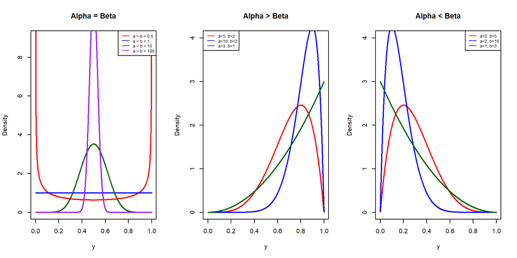

```r
# Values strictly inside (0,1)
y <- seq(0.0001, 0.9999, length.out = 2000)

# Three panels
par(mfrow = c(1, 3))

# (i) Equal parameters
params <- c(0.5, 1, 10, 100)
cols <- c("red", "blue", "darkgreen", "purple")

plot(y, dbeta(y, 0.5, 0.5),
     type = "l", col = cols[1], lwd = 2,
     ylim = c(0, 9),
     main = "Alpha = Beta",
     xlab = "y", ylab = "Density")

for (i in 2:4) {
  lines(y, dbeta(y, params[i], params[i]),
        col = cols[i], lwd = 2)
}

legend("topright",
       legend = paste("a = b =", params),
       col = cols, lty = 1, cex = 0.65)

# (ii) Alpha greater than Beta
plot(y, dbeta(y, 5, 2),
     type = "l", col = "red", lwd = 2,
     ylim = c(0, 4),
     main = "Alpha > Beta",
     xlab = "y", ylab = "Density")

lines(y, dbeta(y, 10, 2),
      col = "blue", lwd = 2)
lines(y, dbeta(y, 3, 1),
      col = "darkgreen", lwd = 2)

legend("topleft",
       legend = c("a=5, b=2", "a=10, b=2",
                  "a=3, b=1"),
       col = c("red", "blue", "darkgreen"),
       lty = 1, cex = 0.65)

# (iii) Alpha less than Beta
plot(y, dbeta(y, 2, 5),
     type = "l", col = "red", lwd = 2,
     ylim = c(0, 4),
     main = "Alpha < Beta",
     xlab = "y", ylab = "Density")

lines(y, dbeta(y, 2, 10),
      col = "blue", lwd = 2)
lines(y, dbeta(y, 1, 3),
      col = "darkgreen", lwd = 2)

legend("topright",
       legend = c("a=2, b=5", "a=2, b=10",
                  "a=1, b=3"),
       col = c("red", "blue", "darkgreen"),
       lty = 1, cex = 0.65)
```

```r
par(mfrow = c(1, 1))
```

**Interpretation**

When alpha = beta, the distribution is symmetric. For alpha = beta = 0.5, it is U-shaped. For alpha = beta = 1, it is uniform. For alpha = beta = 10 or 100, it becomes increasingly concentrated around 0.5.

When alpha > beta, the distribution is concentrated toward larger values of y.

When alpha < beta, the distribution is concentrated toward smaller values of y.

The total alpha + beta controls concentration, while their relative sizes determine the mean and the direction of asymmetry.